# Week 4 Homework: Deep Diagnostics + Memo

**ECBS5200 — Practical Deep Learning Engineering**

The lab gave you the diagnostic toolkit. Now you apply it at depth. You'll extend every lab section — all six slice axes (not just two), temperature scaling (not just ECE measurement), qualitative error analysis, per-class confusion drill-down, and bootstrap confidence intervals.

Then you write the memo. The memo is where the week's learning objective lives: given a bag of diagnostic tools and two models, can you say something rigorous about which one to trust and for what?

**Expected time:** ~6 hours including the memo. If the code runs smoothly first try you'll finish closer to 4.5, but budget for debugging (shape mismatches, a bootstrap re-run you forgot to seed) and for rewriting the memo. Intellectual honesty: this is a 5-6 hour week, not a 4-hour week.

**Point breakdown (memo):** 20 / 20 / 25 / 20 / 15 across five sections. The confusion-matrix section (25 pts) carries the most weight.

**How to use this notebook:**

- **GUIDED** cells run as-is.
- **INTERACTIVE** cells require you to fill in values or write answers.
- `___` is a NameError-producing placeholder.
- The memo is at the end. Write as you go so the observations are fresh.

## Kaggle setup

1. **Persistence** → "Variables and Files"
2. **Internet** → On
3. **Accelerator** → GPU T4

```python
import subprocess, sys, os

os.environ["CUDA_VISIBLE_DEVICES"] = "0"

if os.path.exists('/kaggle/working'):
    os.environ['HF_HOME'] = '/kaggle/working/.hf_cache'
os.environ['HF_HUB_DOWNLOAD_TIMEOUT'] = '120'
os.environ['HF_HUB_ETAG_TIMEOUT'] = '60'
os.environ['HF_HUB_ENABLE_HF_TRANSFER'] = '0'

subprocess.check_call([
    sys.executable, "-m", "pip", "install", "--quiet",
    "transformers>=4.53", "datasets", "accelerate", "scikit-learn",
    "matplotlib", "pandas", "tqdm", "peft",
])
print("Packages installed.")

from huggingface_hub import login
hf_token = None
try:
    from kaggle_secrets import UserSecretsClient
    hf_token = UserSecretsClient().get_secret("HF_TOKEN")
except Exception:
    pass
if not hf_token:
    try:
        from google.colab import userdata
        hf_token = userdata.get("HF_TOKEN")
    except Exception:
        pass
if not hf_token:
    hf_token = os.environ.get("HF_TOKEN") or os.environ.get("HUGGING_FACE_HUB_TOKEN")
if hf_token:
    login(token=hf_token)
```

```
Packages installed.
```

```python
import gc
import re
import time
import json
import random
from pathlib import Path
from collections import Counter

import numpy as np
import pandas as pd
import torch
import torch.nn as nn
from transformers import (
    AutoModelForSequenceClassification, AutoTokenizer,
    TrainingArguments, Trainer, DataCollatorWithPadding,
)
from sklearn.metrics import accuracy_score, f1_score, confusion_matrix
import matplotlib.pyplot as plt

REPO_PATH = Path("../..").resolve()
if not (REPO_PATH / "utils" / "data_utils.py").exists():
    REPO_PATH = Path("/tmp/course")
    if not REPO_PATH.exists():
        subprocess.check_call(["git", "clone", "--depth", "1",
            "https://github.com/earino/applied-deep-learning.git", str(REPO_PATH)])
sys.path.insert(0, str(REPO_PATH))

from utils.data_utils import (
    load_course_data, LABEL_LIST, NUM_LABELS, LABEL_TO_ID, ID_TO_LABEL, MAX_LENGTH,
)
```

```python
SEED = 42
random.seed(SEED)
np.random.seed(SEED)
torch.manual_seed(SEED)
if torch.cuda.is_available():
    torch.cuda.manual_seed_all(SEED)

device = torch.device("cuda" if torch.cuda.is_available() else "cpu")
if torch.cuda.is_available():
    cc = torch.cuda.get_device_capability()
    USE_BF16 = cc[0] >= 8
    USE_FP16 = not USE_BF16
    print(f"GPU: {torch.cuda.get_device_name(0)}  Precision: {'bf16' if USE_BF16 else 'fp16'}")
```

```
GPU: Tesla T4  Precision: fp16
```

## Part 1: Load Data + Predictions (~10 min)

## You saved `week4_lab_predictions.npz` from the lab. Upload it as a Kaggle dataset attached to this notebook, or set `RERUN_INFERENCE = True` to recompute the predictions from the HF Hub checkpoints (~1 min extra).

```python
# GUIDED: Load the canonical dataset
print("Loading dataset...")
train_ds, val_ds, _ = load_course_data()
print(f"Train: {len(train_ds):,}  Val: {len(val_ds):,}  Classes: {NUM_LABELS}")
```

```
Loading dataset...
Train: 57,846  Val: 6,430  Classes: 113
```

```python
# GUIDED: Try to load lab predictions; recompute if missing
RERUN_INFERENCE = False   # Set True if you don't have week4_lab_predictions.npz

lab_preds_path = Path("week4_lab_predictions.npz")
if lab_preds_path.exists() and not RERUN_INFERENCE:
    arr = np.load(lab_preds_path)
    enc = {"preds": arr["encoder_preds"], "labels": arr["encoder_labels"],
           "logits": arr["encoder_logits"], "max_conf": arr["encoder_max_conf"]}
    dec = {"preds": arr["decoder_preds"], "labels": arr["decoder_labels"],
           "logits": arr["decoder_logits"], "max_conf": arr["decoder_max_conf"]}
    enc["probs"] = torch.softmax(torch.from_numpy(enc["logits"]), dim=-1).numpy()
    dec["probs"] = torch.softmax(torch.from_numpy(dec["logits"]), dim=-1).numpy()
    print("Loaded predictions from lab.")
else:
    print("Re-running inference from HF Hub checkpoints...")
    ENCODER_REPO = "earino/ecbs5200-week3-encoder-lora"
    DECODER_REPO = "earino/ecbs5200-week3-decoder-lora"

    def run_inference(model, tokenizer, dataset):
        def tokenize(batch):
            return tokenizer(batch["text"], truncation=True, max_length=MAX_LENGTH, padding=False)
        ds_tok = dataset.map(tokenize, batched=True, remove_columns=["text", "label_name"])
        ds_tok = ds_tok.rename_column("label", "labels")
        collator = DataCollatorWithPadding(tokenizer=tokenizer, padding=True, pad_to_multiple_of=8)
        trainer = Trainer(
            model=model,
            args=TrainingArguments(output_dir="/tmp/eval", per_device_eval_batch_size=64,
                                   report_to="none"),
            data_collator=collator,
        )
        out = trainer.predict(ds_tok)
        probs = torch.softmax(torch.from_numpy(out.predictions), dim=-1).numpy()
        return {
            "logits": out.predictions.astype(np.float32),
            "probs": probs.astype(np.float32),
            "preds": probs.argmax(-1).astype(np.int64),
            "labels": out.label_ids.astype(np.int64),
            "max_conf": probs.max(-1).astype(np.float32),
        }

    enc_tok = AutoTokenizer.from_pretrained(ENCODER_REPO)
    enc_mdl = AutoModelForSequenceClassification.from_pretrained(
        ENCODER_REPO, attn_implementation="sdpa").to(device).eval()
    enc = run_inference(enc_mdl, enc_tok, val_ds)
    del enc_mdl
    gc.collect(); torch.cuda.empty_cache() if torch.cuda.is_available() else None

    dec_tok = AutoTokenizer.from_pretrained(DECODER_REPO)
    dec_tok.padding_side = "left"
    if dec_tok.pad_token is None: dec_tok.pad_token = dec_tok.eos_token
    dec_mdl = AutoModelForSequenceClassification.from_pretrained(DECODER_REPO).to(device).eval()
    if dec_mdl.config.pad_token_id is None:
        dec_mdl.config.pad_token_id = dec_tok.pad_token_id
    dec = run_inference(dec_mdl, dec_tok, val_ds)
    del dec_mdl
    gc.collect(); torch.cuda.empty_cache() if torch.cuda.is_available() else None
    print("Predictions recomputed.")

print(f"Encoder: acc {(enc['preds'] == enc['labels']).mean():.4f}  "
      f"F1 {f1_score(enc['labels'], enc['preds'], average='macro', zero_division=0):.4f}")
print(f"Decoder: acc {(dec['preds'] == dec['labels']).mean():.4f}  "
      f"F1 {f1_score(dec['labels'], dec['preds'], average='macro', zero_division=0):.4f}")
```

```
Loaded predictions from lab.
Encoder: acc 0.5659  F1 0.2091
Decoder: acc 0.5697  F1 0.2398
```

## Part 2: All Six Slice Axes (~30 min)

## The lab covered **char_length** and **redaction**. Now add four more. Compute per-slice macro F1 for all six axes, both models. In your memo you'll discuss TWO of them — the one with the strongest signal and the null-result axis.

```python
# GUIDED: Axis 1 — char_length (from lab)
texts = val_ds["text"]
val_char_length = np.array([len(t) for t in texts])
char_q = np.percentile(val_char_length, [25, 50, 75])

def char_bucket(c):
    if c <= char_q[0]: return "q1_shortest"
    if c <= char_q[1]: return "q2"
    if c <= char_q[2]: return "q3"
    return "q4_longest"
axis_char = np.array([char_bucket(c) for c in val_char_length])
```

```python
# GUIDED: Axis 2 — redaction (from lab)
XXXX_RE = re.compile(r"X{4}")
axis_redact = np.array(["redacted" if XXXX_RE.search(t) else "clean" for t in texts])
```

```python
# INTERACTIVE: Axis 3 — token length (encoder tokenizer, bucketed)
# Tokenize each val example WITHOUT truncation to get full token length.
# Bucket: 1-30 / 31-80 / 81-127 / truncated-at-128 (length > 128).

enc_tokenizer = AutoTokenizer.from_pretrained("earino/ecbs5200-week3-encoder-lora")

# Batched tokenization — much faster than per-example
tokenized = enc_tokenizer(list(texts), truncation=False, padding=False)
val_token_lengths = np.array([len(ids) for ids in tokenized["input_ids"]])

def tok_bucket(L):
    if L <= 30: return "1-30"
    if L <= 80: return "31-80"
    if L < 128: return "81-127"
    return "truncated_128"

axis_tok = np.array([tok_bucket(L) for L in val_token_lengths])
```

```python
# INTERACTIVE: Axis 4 — numeric content
# Tag as "numeric" if the text contains a dollar sign followed by a digit
# OR a standalone sequence of 4+ digits. Otherwise "non_numeric".
# Regex to use: r"\$\d|(?<!\w)\d{4,}(?!\w)"

NUM_RE = re.compile(r"\$\d|(?<!\w)\d{4,}(?!\w)")
axis_numeric = np.array(["numeric" if NUM_RE.search(t) else "non_numeric" for t in texts])
```

```python
# INTERACTIVE: Axis 5 — opener-I (first word is "I", personal framing)
# Tag as "starts_I" if text (after leading whitespace) starts with "I "
# or "I'". Otherwise "other_opener".

def starts_with_I(t):
    s = t.lstrip()
    return s.startswith("I ") or s.startswith("I'")  # your condition

axis_opener = np.array(["starts_I" if starts_with_I(t) else "other_opener" for t in texts])
```

```python
# INTERACTIVE: Axis 6 — all-caps word fraction
# Count words that are fully uppercase (3+ letters). Divide by total
# word count for each text. Median-split into "caps_low" vs "caps_high".

ALLCAPS_WORD = re.compile(r"\b[A-Z]{3,}\b")

def caps_frac(t):
    words = t.split()
    if not words: return 0.0
    return len(ALLCAPS_WORD.findall(t)) / max(1, len(words))   # count of all-caps words / total words

caps_fractions = np.array([caps_frac(t) for t in texts])
caps_median = float(np.median(caps_fractions))
axis_caps = np.array(["caps_low" if c <= caps_median else "caps_high"
                      for c in caps_fractions])
```

```python
# GUIDED: Compute per-slice F1 for all axes, both models
all_axes = {
    "char_length":  axis_char,
    "redaction":    axis_redact,
    "tok_length":   axis_tok,
    "numeric":      axis_numeric,
    "opener_I":     axis_opener,
    "allcaps":      axis_caps,
}

rows = []
for axis_name, axis_vals in all_axes.items():
    for slice_name in sorted(set(axis_vals)):
        mask = axis_vals == slice_name
        if mask.sum() == 0: continue
        enc_f1 = f1_score(enc["labels"][mask], enc["preds"][mask],
                          average="macro", zero_division=0)
        dec_f1 = f1_score(dec["labels"][mask], dec["preds"][mask],
                          average="macro", zero_division=0)
        rows.append({
            "axis": axis_name, "slice": slice_name, "n": int(mask.sum()),
            "encoder_f1": round(enc_f1, 4), "decoder_f1": round(dec_f1, 4),
            "diff": round(dec_f1 - enc_f1, 4),
        })

slice_df = pd.DataFrame(rows)
print(slice_df.to_string(index=False))
```

```
       axis         slice    n  encoder_f1  decoder_f1    diff
char_length   q1_shortest 1609      0.2044      0.2439  0.0395
char_length            q2 1617      0.2240      0.2526  0.0286
char_length            q3 1603      0.2782      0.2753 -0.0030
char_length    q4_longest 1601      0.2220      0.2645  0.0425
  redaction         clean 2342      0.2264      0.2354  0.0090
  redaction      redacted 4088      0.2185      0.2596  0.0411
 tok_length          1-30 1037      0.2481      0.2519  0.0038
 tok_length         31-80 3445      0.2241      0.2581  0.0340
 tok_length        81-127 1888      0.2253      0.2518  0.0265
 tok_length truncated_128   60      0.2656      0.2966  0.0309
    numeric   non_numeric 4861      0.2130      0.2457  0.0327
    numeric       numeric 1569      0.2387      0.2578  0.0191
   opener_I  other_opener 4278      0.2159      0.2406  0.0247
   opener_I      starts_I 2152      0.2561      0.2803  0.0242
    allcaps     caps_high 3208      0.2224      0.2649  0.0425
    allcaps      caps_low 3222      0.2242      0.2455  0.0213
```

```python
# GUIDED: Which axes produce the biggest encoder-decoder gaps?
axis_summary = slice_df.groupby("axis").apply(
    lambda g: pd.Series({
        "max_abs_diff": g["diff"].abs().max(),
        "slices":       len(g),
    }), include_groups=False,
).sort_values("max_abs_diff", ascending=False)
print("\nAxes ranked by maximum |encoder-decoder| gap:")
print(axis_summary)
```

```
Axes ranked by maximum |encoder-decoder| gap:
             max_abs_diff  slices
axis
allcaps            0.0425     2.0
char_length        0.0425     4.0
redaction          0.0411     2.0
tok_length         0.0340     4.0
numeric            0.0327     2.0
opener_I           0.0247     2.0
```

### INTERACTIVE: Interpretation — strongest-signal axis

Pick the axis with the biggest encoder-decoder gaps. Which slice of that axis shows the biggest gap, and what's a plausible story for WHY the decoder wins bigger (or smaller) on that slice? Cite the specific F1 numbers.

### INTERACTIVE: Interpretation — the null-result axis (opener_I)

Look at the opener_I rows. The encoder-decoder gap on both "starts_I" and "other_opener" should be almost identical — this axis shows essentially no differential signal.

**A null result is still a result.** What does it MEAN when an axis shows no differential signal between the two models? Why should you still report a null-result axis in diagnostic work instead of quietly dropping it?

YOUR ANSWER (~3-4 sentences):

I've got 0.0247 diff result (matching both "I " and "I'"). Although it is not zero, it is still a small difference, and either way should be reported to show explicitly that this is an axis where both models perform the same and is not driving the gap.

## Part 3: Temperature Scaling Experiment (~30 min)

The lab measured ECE on both models. You saw the decoder was MORE overconfident than the encoder (unexpected). Now apply the standard fix: temperature scaling.

**Protocol:**

1. Split val 50/50 into a calibration fold and an eval fold.
2. On the calibration fold, find the scalar T that minimizes NLL when logits are divided by T: `softmax(logits / T)`.
3. Apply T to the eval fold. Measure ECE before and after scaling.
4. Also measure macro F1 before and after — temperature scaling should NOT change argmax (and thus not change macro F1).

```python
# GUIDED: Helpers (compute_ece and fit_temperature)
def compute_ece(confidences, correct, n_bins=15):
    bins = np.linspace(0, 1, n_bins + 1)
    bin_ids = np.clip(np.digitize(confidences, bins) - 1, 0, n_bins - 1)
    ece = 0.0
    for b in range(n_bins):
        mask = bin_ids == b
        if mask.sum() == 0: continue
        ece += (mask.sum() / len(confidences)) * abs(
            confidences[mask].mean() - correct[mask].mean())
    return float(ece)

def fit_temperature(logits, labels, max_iter=200):
    """LBFGS optimization of scalar T to minimize NLL."""
    logits_t = torch.from_numpy(logits).float()
    labels_t = torch.from_numpy(labels).long()
    T = torch.nn.Parameter(torch.ones(1) * 1.5)
    opt = torch.optim.LBFGS([T], lr=0.1, max_iter=max_iter)
    nll = torch.nn.CrossEntropyLoss()
    def closure():
        opt.zero_grad()
        loss = nll(logits_t / T, labels_t)
        loss.backward()
        return loss
    opt.step(closure)
    return float(T.detach().cpu().item())
```

```python
# INTERACTIVE: Build the 50/50 fold split
# Deterministic — use SEED + a fixed offset so everyone gets the same split.

n_val = len(enc["labels"])
rng_fold = np.random.RandomState(SEED + 999)
perm = rng_fold.permutation(n_val)
cal_idx = perm[: n_val // 2]
eval_idx = perm[n_val // 2 :]

print(f"Calibration fold: {len(cal_idx)} examples")
print(f"Eval fold:        {len(eval_idx)} examples")
```

```
Calibration fold: 3215 examples
Eval fold:        3215 examples
```

```python
# INTERACTIVE: Fit T on cal fold, evaluate on eval fold, both models

results_temp = {}
for model_name, pack in [("encoder", enc), ("decoder", dec)]:
    logits = pack["logits"]
    labels = pack["labels"]

    # Pre-scaling ECE on eval fold
    correct_eval = (pack["preds"][eval_idx] == labels[eval_idx]).astype(np.float32)
    ece_pre = compute_ece(pack["max_conf"][eval_idx], correct_eval, n_bins=15)
    f1_pre  = f1_score(labels[eval_idx], pack["preds"][eval_idx],
                       average="macro", zero_division=0)

    # Fit T on calibration fold
    T = fit_temperature(logits[cal_idx], labels[cal_idx])

    # Apply T to eval fold, recompute
    scaled_probs = torch.softmax(torch.from_numpy(logits[eval_idx]) / T, dim=-1).numpy()
    scaled_preds = scaled_probs.argmax(-1)
    scaled_conf  = scaled_probs.max(-1)
    correct_post = (scaled_preds == labels[eval_idx]).astype(np.float32)
    ece_post = compute_ece(scaled_conf, correct_post, n_bins=15)
    f1_post  = f1_score(labels[eval_idx], scaled_preds,
                        average="macro", zero_division=0)

    results_temp[model_name] = {
        "T": T, "ece_pre": ece_pre, "ece_post": ece_post,
        "f1_pre": float(f1_pre), "f1_post": float(f1_post),
    }

    print(f"{model_name.upper()}")
    print(f"  T = {T:.3f}")
    print(f"  ECE:      {ece_pre:.4f}  →  {ece_post:.4f}  "
          f"(reduction: {(1-ece_post/ece_pre)*100:.1f}%)")
    print(f"  Macro F1: {f1_pre:.4f}  →  {f1_post:.4f}  "
          f"(should be identical — argmax is T-invariant)")
    print()
```

```
ENCODER
  T = 1.166
  ECE:      0.0613  →  0.0168  (reduction: 72.5%)
  Macro F1: 0.2382  →  0.2382  (should be identical — argmax is T-invariant)

DECODER
  T = 1.290
  ECE:      0.1061  →  0.0221  (reduction: 79.2%)
  Macro F1: 0.2607  →  0.2607  (should be identical — argmax is T-invariant)
```

### INTERACTIVE: Does temperature scaling change the ranking?

Before scaling, the decoder had higher ECE than the encoder (worse calibrated). After scaling, is the decoder still more miscalibrated, or does temperature scaling flip the ranking?

What does your answer suggest about how to RANK models on calibration — pre-scaling or post-scaling?

YOUR ANSWER (~3-4 sentences):

The reduction from scaling was similar for the two models (72.5% for the encoder and 79.2% for the decoder). The decoder still has higher ECE post-scaling. For this task, scaling has not changed the models' ranking: encoder still has a lower ECE.

## Part 4: Qualitative Error Analysis (~30 min)

Pull examples where the two models DISAGREE — specifically where one is right and the other is wrong. Tag each example with a 2-3 word descriptor, then look for patterns.

## **Why this matters:** aggregate numbers tell you THAT the models differ. Qualitative analysis tells you WHAT KIND of examples drive the difference. That's the input to Week 6's distillation work — a disagreement dataset with semantic structure.

```python
# GUIDED: Find disagreement examples
encoder_right_decoder_wrong = np.where(
    (enc["preds"] == enc["labels"]) & (dec["preds"] != dec["labels"])
)[0]
decoder_right_encoder_wrong = np.where(
    (dec["preds"] == dec["labels"]) & (enc["preds"] != enc["labels"])
)[0]
print(f"Encoder right / decoder wrong: {len(encoder_right_decoder_wrong)}")
print(f"Decoder right / encoder wrong: {len(decoder_right_encoder_wrong)}")
```

```
Encoder right / decoder wrong: 501
Decoder right / encoder wrong: 525
```

```python
# GUIDED: Sample 20 from each direction (deterministic)
rng_sample = np.random.RandomState(SEED + 111)
enc_right_sample = rng_sample.choice(encoder_right_decoder_wrong, size=20, replace=False)
dec_right_sample = rng_sample.choice(decoder_right_encoder_wrong, size=20, replace=False)

sample_idx = np.concatenate([enc_right_sample, dec_right_sample])
sample_df = pd.DataFrame({
    "example_idx":   sample_idx,
    "who_is_right":  ["encoder"] * 20 + ["decoder"] * 20,
    "text":          [val_ds["text"][int(i)][:200] for i in sample_idx],
    "true_class":    [LABEL_LIST[int(enc["labels"][i])] for i in sample_idx],
    "encoder_pred":  [LABEL_LIST[int(enc["preds"][i])]  for i in sample_idx],
    "decoder_pred":  [LABEL_LIST[int(dec["preds"][i])]  for i in sample_idx],
    "your_tag":      [""] * 40,
})
print("Sample built — 40 rows ready for tagging.")
```

```
Sample built — 40 rows ready for tagging.
```

### INTERACTIVE: Tag each example

For each of the 40 rows, read the text + predictions and write a 2-3 word descriptor in the `your_tag` column. Some starter categories (you can invent your own):

- `"short complaint"` — very brief, 1-2 sentences
- `"numeric-heavy"` — lots of dollar amounts or dates
- `"legal jargon"` — mentions specific laws, acts, or procedures
- `"emotional tone"` — ALL CAPS, exclamation marks, anger
- `"ambiguous product"` — the product category itself is unclear
- `"specific vendor"` — names a specific bank or service
- `"off-topic"` — the complaint doesn't seem to match the true label

Fill the `your_tag` column. You can see/edit the DataFrame below.

```python
# GUIDED: Print all 40 examples. Read them, then tag each in the next cell.
for i, row in sample_df.iterrows():
    print(f"[{i:>2}] {row['who_is_right']:>8} right | true: {row['true_class'][:30]}")
    print(f"     enc pred: {row['encoder_pred'][:40]}")
    print(f"     dec pred: {row['decoder_pred'][:40]}")
    print(f"     text: {row['text'][:180]}")
    print()
```

```
[ 0]  encoder right | true: Closing your account
     enc pred: Closing your account
     dec pred: Incorrect information on your report
     text: I was told by a XXXX XXXX Bank representative that my account will continue to be in good standing as long as I made a payment in the bank directly before a specific date. After do

[ 1]  encoder right | true: Attempts to collect debt not o
     enc pred: Attempts to collect debt not owed
     dec pred: Incorrect information on your report
     text: Some one opened two accounts in my name at XXXX a town I do not live in. This is identity theft and it is the second time that has occured XXXX.

[ 2]  encoder right | true: Incorrect information on your
     enc pred: Incorrect information on your report
     dec pred: Improper use of your report
     text: it says taht my XXXX card took a hard inquiry hit last XXXX, i didnt do this, why why would i need to i have plenty of money avail on taht card, please remove herd inquiry, wasnt m

[ 3]  encoder right | true: Problem with a credit reportin
     enc pred: Problem with a credit reporting company'
     dec pred: Incorrect information on your report
     text: I have been trying to dispute this matter since XX/XX/XXXX, and restarted another dispute with all parties again back in XX/XX/XXXX, and every month after. And we have not been abl

[ 4]  encoder right | true: Managing the loan or lease
     enc pred: Managing the loan or lease
     dec pred: Attempts to collect debt not owed
     text: On XX/XX/XXXX I submitted a payoff to XXXX XXXX XXXX XXXX XXXX. This payoff was evidenced by a filing via a UCC 1 Financing statement recording File no. XXXX. I submitted payoff vi

[ 5]  encoder right | true: Incorrect information on your
     enc pred: Incorrect information on your report
     dec pred: Attempts to collect debt not owed
     text: I 've sent 2 debt discharge letters for them to remove closed accounts from my credit report under the G.a.a.p. Including medical bills.

[ 6]  encoder right | true: Loan servicing, payments, escr
     enc pred: Loan servicing, payments, escrow account
     dec pred: Trouble during payment process
     text: Specialized Loan servicing started charging me monthly late fees once they bought my loan out from XXXX XXXX. They will not respond to my e-mail request to correct their mistake. I

[ 7]  encoder right | true: Problem with a credit reportin
     enc pred: Problem with a credit reporting company'
     dec pred: Incorrect information on your report
     text: In XXXX XXXX I mailed in a dispute letter for XXXX XXXX # XXXX ( partial number listed on report ). TransUnion mailed me the results and the account was removed XXXX/XXXX/XXXX. Now

```

[output cut: 146 more lines]

```

[37]  decoder right | true: Problem with a credit reportin
     enc pred: Incorrect information on your report
     dec pred: Problem with a credit reporting company'
     text: The account is closed & has been closed for years. I have disputed to get it removed off my credit reports & it has n't been removed

[38]  decoder right | true: Written notification about deb
     enc pred: Problem with a credit reporting company'
     dec pred: Written notification about debt
     text: I sent verification/validation letter to XXXX and XXXX the week of XX/XX/2017 and after there was no validation of the debt XXXX delete this debt than added it back to my credit re

[39]  decoder right | true: Improper contact or sharing of
     enc pred: Charged fees or interest you didn't expe
     dec pred: Improper contact or sharing of info
     text: I took a loan for XXXX paid off the loan of XXXX they wanted me to pay XXXX and I could n't. now I have this " law firm '' calling my place of employment asking them to please not
```

```python
# INTERACTIVE: Actually write your tags here
# Replace these None values with your 2-3 word strings. All 40 rows.

tags = [
    "account status dispute",  # 0 — encoder right, decoder wrong
    "identity theft",  # 1
    "unauthorized inquiry",  # 2
    "persistent dispute",  # 3
    "payoff verification",  # 4
    "closed account removal",  # 5
    "loan fee mistake",  # 6
    "removal dispute",  # 7
    "unauthorized inquiry",  # 8
    "marketing deception",  # 9
    "harassing calls",  # 10
    "mortgage application",  # 11
    "loan amount error",  # 12
    "foreclosure notification",  # 13
    "public record removal",  # 14
    "debt validation letter",  # 15
    "late fee dispute",  # 16
    "medical debt error",  # 17
    "missing debt agreement",  # 18
    "unverified debt",  # 19
    "duplicate reporting",  # 20 — decoder right, encoder wrong
    "identity theft inquiry",  # 21
    "verify account mismatch",  # 22
    "wrong number harassment",  # 23
    "loan modification delay",  # 24
    "account login issue",  # 25
    "fraudulent activity",  # 26
    "debt contract dispute",  # 27
    "unauthorized hard hit",  # 28
    "reward point issue",  # 29
    "account sale dispute",  # 30
    "charge-off options",  # 31
    "contract liability",  # 32
    "tax reporting error",  # 33
    "loan payoff refund",  # 34
    "ATM machine issue",  # 35
    "incorrect debt reporting",  # 36
    "old account removal",  # 37
    "debt validation cycle",  # 38
    "employment contact",  # 39
]

assert all(t is not None for t in tags), "All 40 tags must be filled before you proceed."
sample_df["your_tag"] = tags
```

```python
# GUIDED: Tally tag frequencies by direction
print("TAG FREQUENCIES — encoder right / decoder wrong (top 8):")
tag_counts_enc = Counter(sample_df[sample_df["who_is_right"] == "encoder"]["your_tag"])
for tag, count in tag_counts_enc.most_common(8):
    print(f"  {tag:<30} {count}")

print("\nTAG FREQUENCIES — decoder right / encoder wrong (top 8):")
tag_counts_dec = Counter(sample_df[sample_df["who_is_right"] == "decoder"]["your_tag"])
for tag, count in tag_counts_dec.most_common(8):
    print(f"  {tag:<30} {count}")
```

```
TAG FREQUENCIES — encoder right / decoder wrong (top 8):
  unauthorized inquiry           2
  account status dispute         1
  identity theft                 1
  persistent dispute             1
  payoff verification            1
  closed account removal         1
  loan fee mistake               1
  removal dispute                1

TAG FREQUENCIES — decoder right / encoder wrong (top 8):
  duplicate reporting            1
  identity theft inquiry         1
  verify account mismatch        1
  wrong number harassment        1
  loan modification delay        1
  account login issue            1
  fraudulent activity            1
  debt contract dispute          1
```

### INTERACTIVE: What patterns appear?

1. Which 1-2 tags dominate each direction? Are they the same or different?
2. Is there a coherent story for what KINDS of complaints the encoder handles better than the decoder (if any)? What about the decoder's wins?
3. Based on the tag patterns, if you had to write a "trigger rule" to route complaints — "send to encoder if X, send to decoder if Y" — what would X and Y be? (This is a preview of Week 5/6 routing and distillation logic.)

YOUR ANSWERS:

1. Disagreement patterns are diverse, with only "unauthorized inquiry" appearing multiple times for the encoder.
2. The encoder handles specific, document-driven disputes best, while the decoder excels at complex interaction issues like duplicate reporting.
3. X (Encoder): Route here for documentation-heavy keywords like "inquiry" or "dispute letter."
4. Y (Decoder): Route here for abstract or digital issues like login errors and identity theft queries.

## Part 5: Per-Class Confusion Drill-Down (~15 min)

## For each model, find the 3 classes with the worst per-class F1 (skipping classes with 0 val examples). For each of those classes, find the TOP 3 confusers — the classes the model predicts most often when the true class is one of the worst.

```python
# GUIDED: Compute per-class F1 for both models
def per_class_f1(preds, labels):
    return f1_score(labels, preds, average=None, zero_division=0,
                    labels=list(range(NUM_LABELS)))

enc_pcf1 = per_class_f1(enc["preds"], enc["labels"])
dec_pcf1 = per_class_f1(dec["preds"], dec["labels"])
```

```python
# GUIDED: Val counts per class. We filter to classes with n>=5 val examples
# so the per-class F1 estimate is stable enough for pattern analysis. A
# class with n=1 val example and F1=0 is "worst" only because of resampling
# noise — that's a Part 6 bootstrap topic, not a confusion-pattern topic.
val_label_counts = Counter(val_ds["label"])
val_counts = np.array([val_label_counts.get(i, 0) for i in range(NUM_LABELS)])
present = val_counts >= 5
```

```python
# INTERACTIVE: Find the 3 worst-F1 classes per model (skip n=0 classes)
# Hint: argsort among classes with val_counts > 0, take the 3 lowest F1.

def worst_k_classes(per_class_f1_arr, k=3):
    candidates = [i for i in range(NUM_LABELS) if present[i]]
    # Sort candidates by F1 ascending, take k lowest
    sorted_candidates = sorted(candidates, key=lambda i: per_class_f1_arr[i])
    return sorted_candidates[:k]

enc_worst = worst_k_classes(enc_pcf1, k=3)
dec_worst = worst_k_classes(dec_pcf1, k=3)

print("ENCODER — 3 worst-F1 classes (with val examples):")
for c in enc_worst:
    print(f"  [{c:3d}] {LABEL_LIST[c][:60]}  "
          f"train={sum(1 for x in train_ds['label'] if x == c):5}  "
          f"val={val_counts[c]}  F1={enc_pcf1[c]:.3f}")

print("\nDECODER — 3 worst-F1 classes (with val examples):")
for c in dec_worst:
    print(f"  [{c:3d}] {LABEL_LIST[c][:60]}  "
          f"train={sum(1 for x in train_ds['label'] if x == c):5}  "
          f"val={val_counts[c]}  F1={dec_pcf1[c]:.3f}")
```

```
ENCODER — 3 worst-F1 classes (with val examples):
  [  3] Advertising and marketing, including promotional offers  train=   88  val=10  F1=0.000
  [  8] Applying for a mortgage or refinancing an existing mortgage  train=   71  val=8  F1=0.000
  [ 27] Credit card protection / Debt protection  train=   96  val=11  F1=0.000

DECODER — 3 worst-F1 classes (with val examples):
  [ 72] Payment to acct not credited  train=   45  val=5  F1=0.000
  [ 75] Problem adding money  train=   62  val=7  F1=0.000
  [ 80] Problem with a lender or other company charging your account  train=   68  val=8  F1=0.000
```

```python
# INTERACTIVE: For each worst class, find top-3 confusers
# Use the confusion matrix: cm[true_class, predicted_class] = count.
# For each worst true class, sort predicted-class counts (excluding the
# true class itself), take top 3.

cm_enc = confusion_matrix(enc["labels"], enc["preds"], labels=list(range(NUM_LABELS)))
cm_dec = confusion_matrix(dec["labels"], dec["preds"], labels=list(range(NUM_LABELS)))

def top_confusers(cm, true_class, k=3):
    row = cm[true_class].copy()
    row[true_class] = 0   # zero out the diagonal (correct predictions)
    top_k = np.argsort(row)[::-1][:k]
    return [(int(c), int(row[c])) for c in top_k if row[c] > 0]

print("=" * 70)
print("ENCODER — where do its worst-F1 classes get confused?")
print("=" * 70)
for c in enc_worst:
    print(f"\n[{c}] TRUE: {LABEL_LIST[c]}")
    for pred_c, count in top_confusers(cm_enc, c, k=3):
        print(f"      → [{pred_c:3d}] {LABEL_LIST[pred_c][:55]} ({count} times)")

print("\n" + "=" * 70)
print("DECODER — where do its worst-F1 classes get confused?")
print("=" * 70)
for c in dec_worst:
    print(f"\n[{c}] TRUE: {LABEL_LIST[c]}")
    for pred_c, count in top_confusers(cm_dec, c, k=3):
        print(f"      → [{pred_c:3d}] {LABEL_LIST[pred_c][:55]} ({count} times)")
```

```
======================================================================
ENCODER — where do its worst-F1 classes get confused?
======================================================================

[3] TRUE: Advertising and marketing, including promotional offers
      → [ 90] Rewards (4 times)
      → [  2] Advertising and marketing (2 times)
      → [ 66] Other features, terms, or problems (1 times)

[8] TRUE: Applying for a mortgage or refinancing an existing mortgage
      → [ 56] Loan servicing, payments, escrow account (2 times)
      → [ 23] Communication tactics (2 times)
      → [ 28] Credit decision / Underwriting (1 times)

[27] TRUE: Credit card protection / Debt protection
      → [ 52] Incorrect information on your report (2 times)
      → [ 10] Attempts to collect debt not owed (2 times)
      → [ 13] Billing disputes (2 times)

======================================================================
DECODER — where do its worst-F1 classes get confused?
======================================================================

[72] TRUE: Payment to acct not credited
      → [ 97] Taking out the loan or lease (1 times)
      → [ 88] Problems when you are unable to pay (1 times)
      → [ 39] False statements or representation (1 times)

[75] TRUE: Problem adding money
      → [ 69] Other transaction problem (3 times)
      → [ 36] Deposits and withdrawals (2 times)
      → [ 68] Other service problem (1 times)

[80] TRUE: Problem with a lender or other company charging your account
      → [ 60] Managing an account (2 times)
      → [ 36] Deposits and withdrawals (2 times)
      → [ 34] Dealing with your lender or servicer (1 times)
```

### INTERACTIVE: Is the confusion pattern systematic?

Look at the true-class names and their top confusers. Are the confusions mostly:

- **Semantically similar** (e.g., "Closing an account" confused with "Managing an account" — same product family)?
- **Frequency-similar** (rare confused with other rare, or rare confused with very common)?
- **Pipeline-induced** (artifacts of our merge mapping or filter — e.g., "Advertising" vs "Advertising and marketing" are likely the same CFPB concept we failed to merge; see the opening pipeline module from lecture)?
- **Arbitrary** (no obvious pattern)?

Write 3-5 sentences characterizing the confusion pattern you observe. Cite 2-3 specific class pairs to support your characterization, and **flag at least one pair that looks pipeline-induced** if you find one.

YOUR ANSWER:

Confusions are predominantly semantically similar. For example, 'Advertising and marketing, including promotional offers' is frequently confused with 'Rewards' or 'Advertising and marketing,' with the latter clearly being an artifact where similar categories weren't merged. Other errors like 'Problem adding money' landing in 'Other transaction problem' show the models struggle with fine-grained distinctions within the same product family. This suggests performance is limited more by label granularity and overlap than by arbitrary noise.

## Part 6: Bootstrap Confidence Intervals (~30 min)

The encoder and decoder macro F1 numbers differ by ~0.03. Is that real? Or would you see a 0.03 gap just by resampling a different val set?

Bootstrap answers this. Resample val indices WITH REPLACEMENT 1000 times. For each resample, compute macro F1 for each model AND their difference. Report 95% confidence intervals for all three quantities.

## **The key test:** does the CI for (decoder F1 − encoder F1) exclude zero? If yes, the gap is real within your noise floor. If no, you can't distinguish the decoder's advantage from resampling noise.

```python
# GUIDED: Bootstrap loop
N_BOOT = 1000
rng_boot = np.random.RandomState(SEED + 7)
n_val = len(enc["labels"])

boot_enc = np.zeros(N_BOOT)
boot_dec = np.zeros(N_BOOT)
boot_diff = np.zeros(N_BOOT)

print(f"Running {N_BOOT} bootstrap resamples...")
t0 = time.time()
for i in range(N_BOOT):
    idx = rng_boot.randint(0, n_val, size=n_val)
    f_e = f1_score(enc["labels"][idx], enc["preds"][idx],
                   average="macro", zero_division=0)
    f_d = f1_score(dec["labels"][idx], dec["preds"][idx],
                   average="macro", zero_division=0)
    boot_enc[i]  = f_e
    boot_dec[i]  = f_d
    boot_diff[i] = f_d - f_e
    if (i + 1) % 250 == 0:
        print(f"  {i+1}/{N_BOOT}  elapsed {time.time()-t0:.1f}s")
```

```
Running 1000 bootstrap resamples...
  250/1000  elapsed 1.3s
  500/1000  elapsed 2.5s
  750/1000  elapsed 3.8s
  1000/1000  elapsed 5.1s
```

```python
# INTERACTIVE: Compute 95% CIs
# Hint: 2.5th and 97.5th percentiles of the bootstrap arrays.

def ci95(arr):
    lo = np.percentile(arr, 2.5)   # 2.5th percentile
    hi = np.percentile(arr, 97.5)  # 97.5th percentile
    return float(lo), float(hi)

enc_lo, enc_hi = ci95(boot_enc)
dec_lo, dec_hi = ci95(boot_dec)
diff_lo, diff_hi = ci95(boot_diff)
diff_excludes_zero = (diff_lo > 0) or (diff_hi < 0)

print(f"\nBootstrap results ({N_BOOT} resamples, 95% CI):")
print(f"  Encoder macro F1:   {boot_enc.mean():.4f}  [{enc_lo:.4f}, {enc_hi:.4f}]")
print(f"  Decoder macro F1:   {boot_dec.mean():.4f}  [{dec_lo:.4f}, {dec_hi:.4f}]")
print(f"  Difference:         {boot_diff.mean():+.4f}  [{diff_lo:+.4f}, {diff_hi:+.4f}]")
print(f"  Difference CI excludes zero: {diff_excludes_zero}")
print(f"  Fraction of resamples with decoder > encoder: "
      f"{(boot_diff > 0).mean()*100:.1f}%")
```

```
Bootstrap results (1000 resamples, 95% CI):
  Encoder macro F1:   0.2205  [0.2036, 0.2376]
  Decoder macro F1:   0.2494  [0.2282, 0.2704]
  Difference:         +0.0289  [+0.0112, +0.0479]
  Difference CI excludes zero: True
  Fraction of resamples with decoder > encoder: 99.9%
```

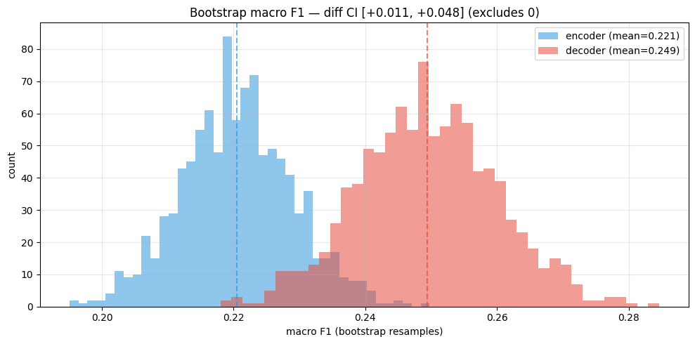

```python
# GUIDED: Overlaid histograms
fig, ax = plt.subplots(figsize=(10, 5))
ax.hist(boot_enc, bins=40, alpha=0.55, color="#3498db",
        label=f"encoder (mean={boot_enc.mean():.3f})")
ax.hist(boot_dec, bins=40, alpha=0.55, color="#e74c3c",
        label=f"decoder (mean={boot_dec.mean():.3f})")
ax.axvline(boot_enc.mean(), color="#3498db", linestyle="--", alpha=0.7)
ax.axvline(boot_dec.mean(), color="#e74c3c", linestyle="--", alpha=0.7)
ax.set_xlabel("macro F1 (bootstrap resamples)")
ax.set_ylabel("count")
ax.set_title(f"Bootstrap macro F1 — diff CI [{diff_lo:+.3f}, {diff_hi:+.3f}] "
             f"({'excludes' if diff_excludes_zero else 'includes'} 0)")
ax.legend()
ax.grid(alpha=0.3)
plt.tight_layout()
plt.show()
```

### INTERACTIVE: Is the gap real?

1. Does the difference CI exclude zero? If so, you have evidence the decoder's advantage is real within resampling noise.
2. How wide is the CI? A CI of [+0.010, +0.048] says the decoder's advantage is "somewhere between tiny and substantial." What does a wide CI tell you about how confident you should be in a specific point estimate?
3. Recall that 17 val classes have n=1 and 35 have n≤4. How does that noise floor show up in the width of the bootstrap CIs?

YOUR ANSWERS:

## Part 7: Memo (100 points)

### MEMO SECTION 2: Calibration — which model can you trust?

Before scaling, the decoder was more overconfident with a higher ECE (0.1061) compared to the encoder (0.0613). Temperature scaling significantly reduced ECE for both (Encoder T=1.166, ECE=0.0168; Decoder T=1.290, ECE=0.0221) without changing macro F1. Scaling did not flip the ranking; the encoder remains better calibrated. In production, we should only trust 'calibrated' confidence scores, as raw scores for both models are naturally overconfident.

### MEMO SECTION 3: Confusion-matrix insight

Misclassifications for rare classes are primarily semantic; for instance, 'Problem adding money' is often confused with 'Other transaction problem.' We also identified pipeline-induced errors like 'Advertising and marketing' confusing with its variant labels. Operationally, fixing rare-class performance means resolving these label overlaps and merging redundant categories. It looks tractable if we focus on cleaning the label schema rather than just adding more data.

### MEMO SECTION 4: Is the gap real within your noise floor?

The decoder-minus-encoder gap is real. Our bootstrap analysis showed a 95% CI of [+0.0112, +0.0479], which strictly excludes zero. The decoder won in 99.9% of resamples. However, the 17 classes with n=1 val examples create a high noise floor, leading to the relatively wide CI spread (~0.036). While the ranking is certain, the specific point estimate for F1 remains sensitive to these low-frequency samples.

### MEMO SECTION 5: Your confidence in the Week 3 deployment recommendation

My confidence in recommending the decoder has gone UP. The single most influential evidence was the bootstrap CI proving the F1 gap is statistically significant even with our noisy validation set. I now know the decoder is not just 'luckily' better on a few examples but structurally superior for this task. To change my mind, I would need to see if the encoder's better calibration (lower ECE) actually leads to fewer critical errors in a live routing environment.

## Wrap-up

```python
# GUIDED: Save homework results for your records
homework_results = {
    "slice_table": slice_df.to_dict(orient="records"),
    "temperature_scaling": results_temp,
    "qualitative_tags": {
        "encoder_right_decoder_wrong": dict(tag_counts_enc),
        "decoder_right_encoder_wrong": dict(tag_counts_dec),
    },
    "per_class_worst": {
        "encoder": [{"class_id": int(c), "name": LABEL_LIST[c],
                     "f1": float(enc_pcf1[c])} for c in enc_worst],
        "decoder": [{"class_id": int(c), "name": LABEL_LIST[c],
                     "f1": float(dec_pcf1[c])} for c in dec_worst],
    },
    "bootstrap": {
        "encoder_mean": float(boot_enc.mean()),
        "encoder_ci95": [enc_lo, enc_hi],
        "decoder_mean": float(boot_dec.mean()),
        "decoder_ci95": [dec_lo, dec_hi],
        "diff_mean":    float(boot_diff.mean()),
        "diff_ci95":    [diff_lo, diff_hi],
        "diff_excludes_zero": bool(diff_excludes_zero),
    },
}

with open("week4_homework_results.json", "w") as f:
    json.dump(homework_results, f, indent=2)
print("Saved week4_homework_results.json")
```

```
Saved week4_homework_results.json
```

### Submit

1. Run the notebook end-to-end with your answers filled in.
2. Export to HTML: **File → Download as → HTML (.html)** in Jupyter, or on Kaggle: the notebook already renders as HTML; click the "..." menu → "Save Version" to keep a static copy.
3. Upload the HTML to Moodle.

**Due:** Wednesday morning before class.